# Exploration of the relationship between the uniform and exponential distributions

February 2, 2018

## Introduction

- A shiny app was created for the analysis
- The basic idea is to show that if you sample a number of points from a uniform distribution and order them by size, then the inter-point distances follow an exponential distribution (at least approximately)
- In the app the user can set the sample size and the number of bins used in histograms
- a Kolomogorov-Smirnov (KS) two-sample test gives a quantitative measure of how close the two distribtions are
- In these slides selected parts of the app HTML output are produced with R Markdown. A link to the full app output is provided
- The slides can be used for teaching students about the exponential properties of the uniform distribution!

## Code for the Shiny app

- The ui and server files can be found in the following GitHub repository https://github.com/peterfurness/DevelopingDataProducts
- A simple monte carlo approach is used to generate the samples
- the ks.test function is used for the two-sample KS test

## Selected output from the Shiny app

#### See https://peterfurness.shinyapps.io/DDP_Course_project

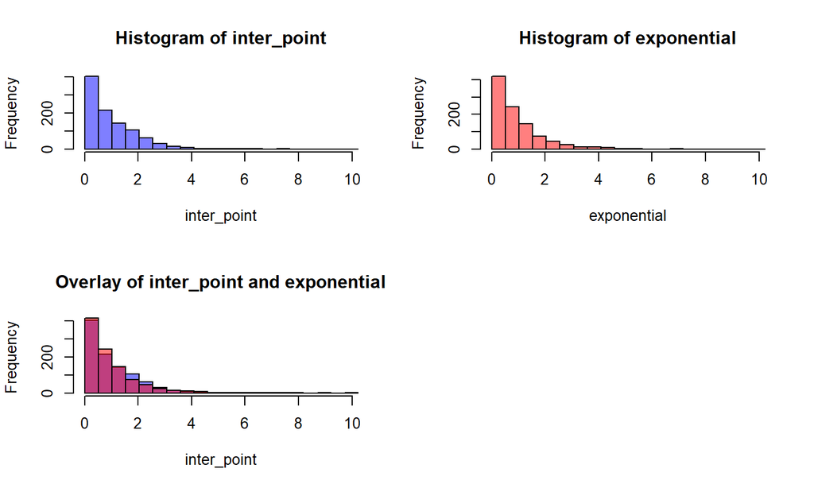

```
## KS Test:  n_unif =  1000 D =  0.05428 p-value =  0.1052
```

## Conclusion

- Running the app demostrates that the distribution of inter-point differences from a sample of uniform values is, at least approximately, exponential
- There are some clear limitations in our analysis. For example, in this approach the inter-point differences will always be bounded above, whereas samples from an exponential distribution are not
- A more sophisticated approach would be needed to explore the full asymptotic properties of the distributions